# UTR analysis on *Parhyale hawaiensis* asymmetric genes

Manuel Jara-Espejo

# 1 Introduction

This document describe the analysis on UTRs for genes defined as asymmetric, which are potentially involved in the establishment of lineage commitment in 8-cell embryos. Next, I used MEME suite to identify enriched RNA-binding motifs in the subset of blastomere-specific transcripts

# 2 UTR length analysis

```r
knitr::opts_chunk$set(message=F,warning=F,echo=T)
#load libraries
library(reshape2)
library(ggpubr)
library(tibble)
library(ggplotify)
library(RColorBrewer)
library(dplyr)
library(tidyr)
library(ggplot2)
```

Filter *Transdecoder* annotation to keep UTR features

```r
phaw_utrs = read.table("/drives/ssd1/manuel/phaw/2022_analysis/annotation/protein_coding_genes/transdecoder/unigenes/transcripts_cdhit_0.95.fa.transdecoder.genome_unigenes.gff3",sep= "\t",stringsAsFactors = F, header=F)
phaw_utrs <- phaw_utrs %>% filter(grepl(pattern = "UTR",x = V3)) %>% mutate(utr_length = abs(V5 - V4) + 1)
phaw_utrs <- phaw_utrs %>% separate(V9, into = c(NA,"gene_id"),sep=";") %>% mutate(gene_id=gsub("Parent=","",gene_id))
head(phaw_utrs %>% filter(V3 == "five_prime_UTR"))
```

|  | V1 | V2 | V3 | V4 | V5 | V6 | V7 | V8 | gene_id | utr_length |
| --- | --- | --- | --- | --- | --- | --- | --- | --- | --- | --- |
| 1 | Scaffold_1137_HRSCAF_3071 | transdecoder | five_prime_UTR | 16433460 | 16433766 | . | - | . | MSTRG.1000.1.p1 | 307 |
| 2 | Scaffold_203_HRSCAF_1201 | transdecoder | five_prime_UTR | 57197929 | 57198038 | . | - | . | MSTRG.10000.1.p1 | 110 |
| 3 | Scaffold_203_HRSCAF_1201 | transdecoder | five_prime_UTR | 57145265 | 57150166 | . | + | . | MSTRG.10001.1.p1 | 4902 |
| 4 | Scaffold_203_HRSCAF_1201 | transdecoder | five_prime_UTR | 57150858 | 57151641 | . | + | . | MSTRG.10001.1.p1 | 784 |
| 5 | Scaffold_203_HRSCAF_1201 | transdecoder | five_prime_UTR | 57715564 | 57717620 | . | - | . | MSTRG.10003.2.p1 | 2057 |
| 6 | Scaffold_203_HRSCAF_1201 | transdecoder | five_prime_UTR | 57227418 | 57228039 | . | + | . | MSTRG.10004.1.p1 | 622 |

5’ UTR stats and length

```r
paste("Genes with annotated 5' UTR:",
phaw_utrs %>% filter(V3 == "five_prime_UTR") %>% select(gene_id) %>% unique() %>% nrow())
```

```
[1] "Genes with annotated 5' UTR: 16903"
```

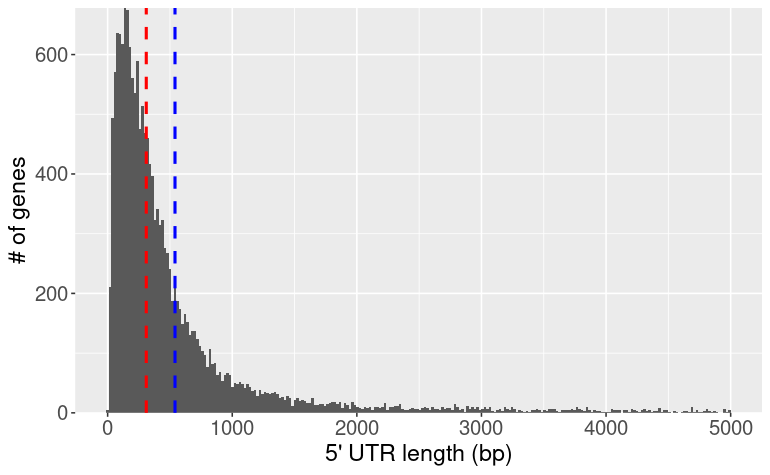

```r
#5 UTR length
phaw_utrs %>% filter(V3 == "five_prime_UTR") %>% group_by(gene_id) %>% summarise(utr_length = sum(utr_length)) %>% # filter(utr_length >= 30) %>% dim()
filter(utr_length <= 5000) %>%
ggplot(aes(x=utr_length)) + geom_histogram(bins = 250) +
  geom_vline(aes(xintercept=mean(utr_length)),color="blue", linetype="dashed", size=1) +
  geom_vline(aes(xintercept=median(utr_length)),color="red", linetype="dashed", size=1) + scale_y_continuous(expand = c(0, 0)) +
theme(axis.text = element_text(size=14),axis.title = element_text(size=16)) + xlab("5' UTR length (bp)") +
  ylab("# of genes")
```

3’ UTR stats and length

```r
paste("Genes with annotated 3' UTR:",
phaw_utrs %>% filter(V3 == "three_prime_UTR") %>% select(gene_id) %>% unique() %>% nrow())
```

```
[1] "Genes with annotated 3' UTR: 18265"
```

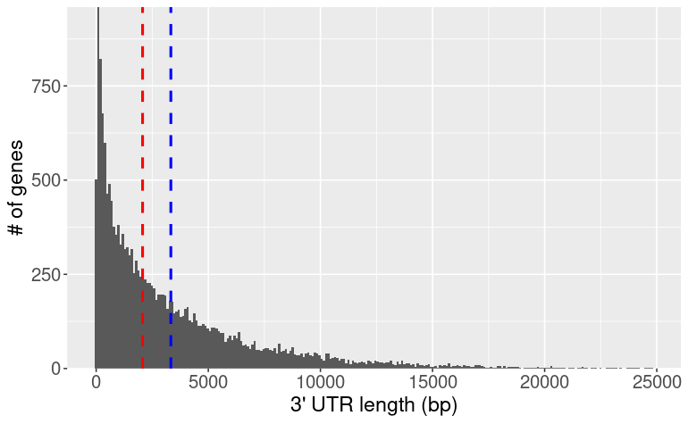

```r
#5 UTR length
phaw_utrs %>% filter(V3 == "three_prime_UTR") %>% group_by(gene_id) %>% summarise(utr_length = sum(utr_length)) %>%
  filter(utr_length <= 25000) %>%
  ggplot(aes(x=utr_length)) + geom_histogram(bins = 250) + geom_vline(aes(xintercept=mean(utr_length)),color="blue", linetype="dashed",
                                                                      size=1) +
  geom_vline(aes(xintercept=median(utr_length)),color="red", linetype="dashed", size=1)  + scale_y_continuous(expand = c(0, 0)) +
  theme(axis.text = element_text(size=14),axis.title = element_text(size=16)) +
  xlab("3' UTR length (bp)") + ylab("# of genes")
```

# 3 Extraction of UTR sequences after protein-coding genes annotation.

I used agat suite to extract UTR sequences for each gene. This tool used the protein-coding annotation generated by *Transdecoder*, which contains CDS and UTR features per gene. The sequences were extracted from the *Phaw5.1* assembly.

Extract sequences and save them as fasta file

```bash
#conda activate agat

#Extract 5'UTR sequences
agat_sp_extract_sequences.pl -g ~/manuel/phaw/2022_analysis/annotation/protein_coding_genes/transdecoder/unigenes/transcripts_cdhit_0.95.fa.transdecoder.genome_unigenes.gtf -f ~/manuel/phaw/2022_analysis/phaw_gapfilling/TGS-GapCloser_anlysis/results_sambaAsm/change_scafNames/phaw_sambaAsm.scaff_seqs_editedScafNames.fa -t five_prime_utr --merge -o five_prime_utr.fasta
#Extract 3'UTR sequences
agat_sp_extract_sequences.pl -g ~/manuel/phaw/2022_analysis/annotation/protein_coding_genes/transdecoder/unigenes/transcripts_cdhit_0.95.fa.transdecoder.genome_unigenes.gtf -f ~/manuel/phaw/2022_analysis/phaw_gapfilling/TGS-GapCloser_anlysis/results_sambaAsm/change_scafNames/phaw_sambaAsm.scaff_seqs_editedScafNames.fa -t three_prime_utr --merge -o three_prime_utr.fasta
```

Convert .fasta to .tbl and filter by blastomere-specific gene IDs. Use FastaToTbl script.

```bash
echo "5'UTR sequences in .tbl format"
echo ""
/drives/ssd1/manuel/FastaToTbl.sh /drives/ssd1/manuel/phaw/2022_analysis/annotation/protein_coding_genes/utr_analysis/five_prime_utr.fasta |
head -5
#The ouput files are:
#five_prime_utr.fasta.tbl
#three_prime_utr.fasta.tbl
```

```
5'UTR sequences in .tbl format

MSTRG.18409.1.p1 gene=MSTRG.18409 name="ORF type:complete len:522 (+),score=99.61,sp|P23654|NRT_DROME|37.919|" seq_id=Scaffold_282861_HRSCAF_288508.0 type=five_prime_utr   GGTGAGGGGTATAGGTGTCGAAGGTCCTGTTACAGCGCAACTCTGGGTGCCGCGTTTCAT…
MSTRG.18410.2.p1 gene=MSTRG.18410 name="ORF type:complete len:354 (+),score=80.42" seq_id=Scaffold_282861_HRSCAF_288508.0 type=five_prime_utr   CGGGAAAATTAAGCTTATCGATCCACTTGAAGGCATACGGAGCTTGAGAATATTTTACTC…
MSTRG.18412.1.p1 gene=MSTRG.18412 name="ORF type:complete len:263 (+),score=46.82,sp|P23654|NRT_DROME|39.207|" seq_id=Scaffold_282861_HRSCAF_288508.0 type=five_prime_utr   GGCAATGTTGTGGAGGGGGACGAGGACTGTCTCTTCCTAGACATTTTCACGCCCAAGCTG…
MSTRG.18413.2.p1 gene=MSTRG.18413 name="ORF type:complete len:1088 (+),score=369.41,sp|Q92539|LPIN2_HUMAN|43.116|" seq_id=Scaffold_282861_HRSCAF_288508.0 type=five_prime_utr   CCTCGTTGCAGTGCCAGTTTTTGGTAACATGGCGAAGCTTTTGAAGGCTAATCTTCCCTT…
MSTRG.18421.1.p1 gene=MSTRG.18421 name="ORF type:complete len:153 (+),score=35.77,sp|A4FUY7|MOC2B_BOVIN|54.676|" seq_id=Scaffold_282861_HRSCAF_288508.0 type=five_prime_utr TGAATTAGCTTGAGGACAAACAAAAAGAGAGACAAACACAACTAAAATATAACCTCTCTT…
```

Filter 3’UTR sequences using blastomere-specific IDs The potential candidates were selected if their expression was 10 times higher compared to the other seven blastomeres. We also used other fold change thresholds like 2 and 5 to see how this parameter impacted the identified genes. The .tbl file was filtered by gene ID and UTR lenght (>= 30bp) and converted back to .fasta format.

ECTODERMAL candidates

```bash
#grep -Fwf ecto_candidatesFC10_all.txt ../three_prime_utr.fasta.tbl | awk -F "\t" 'length($2) >= 30 { print }'| TblToFasta.sh > ectofc10_threeUTR.fa
echo "# of potential candidates"
wc -l /drives/ssd1/manuel/phaw/2022_analysis/annotation/protein_coding_genes/utr_analysis/ectodermal_genes/ecto_candidatesFC10_all.txt
echo "# of UTR sequences retrieved"
grep -c ">" /drives/ssd1/manuel/phaw/2022_analysis/annotation/protein_coding_genes/utr_analysis/ectodermal_genes/ectofc10_threeUTR_all.fa
```

```
# of potential candidates
333 /drives/ssd1/manuel/phaw/2022_analysis/annotation/protein_coding_genes/utr_analysis/ectodermal_genes/ecto_candidatesFC10_all.txt
# of UTR sequences retrieved
302
```

GERMLINE candidates

```bash
#grep -Fwf g_candidatesFC10_all.txt ../three_prime_utr.fasta.tbl | awk -F "\t" 'length($2) >= 30 { print }' | TblToFasta.sh > g_threeUTR_all.fa
echo "# of potential candidates"
wc -l /drives/ssd1/manuel/phaw/2022_analysis/annotation/protein_coding_genes/utr_analysis/germcell_genes/g_candidatesFC10_all.txt
echo "# of UTR sequences retrieved"
grep -c ">" /drives/ssd1/manuel/phaw/2022_analysis/annotation/protein_coding_genes/utr_analysis/germcell_genes/g_threeUTR_all.fa
```

```
# of potential candidates
19 /drives/ssd1/manuel/phaw/2022_analysis/annotation/protein_coding_genes/utr_analysis/germcell_genes/g_candidatesFC10_all.txt
# of UTR sequences retrieved
14
```

## 3.1 Motif enrichement analysis on blastomere-specific UTR sequences

Ectodermal candidates - 3’ UTR Motif enrichment

```r
#Meme Suite path: /home/zoo/zool2528/meme/bin/xstreme
#nohup ~/meme/bin/xstreme -p /drives/ssd1/manuel/phaw/2022_analysis/annotation/protein_coding_genes/utr_analysis/ectodermal_genes/ectofc10_threeUTR_all.fa --n ../three_prime_utr.fasta --o ecto_xstreme_FC10_allTxs --dna --dna2rna --meme-mod zoops --meme-p 4 --sea-noseqs --meme-nmotifs 50 --align center --m /drives/ssd1/manuel/miniconda3/motif_databases/RNA/Ray2013_rbp_All_Species.meme -maxw 10 &
```

Ouput

```bash
ls /drives/ssd1/manuel/phaw/2022_analysis/annotation/protein_coding_genes/utr_analysis/ectodermal_genes/ecto_xstreme_FC10_allTxs | tail
```

```
sea_disc_msgs.txt
sea_disc_out
sea_msgs.txt
sea_out
streme_msgs.txt
streme_out
streme_tomtom_out
xstreme.html
xstreme.tsv
xstreme.txt
```

Germline candidates - 3’ UTR Motif enrichment

```r
#Meme Suite path: /home/zoo/zool2528/meme/bin/xstreme
#nohup ~/meme/bin/xstreme -p /drives/ssd1/manuel/phaw/2022_analysis/annotation/protein_coding_genes/utr_analysis/ectodermal_genes/ectofc10_threeUTR_all.fa --n ../three_prime_utr.fasta --o ecto_xstreme_FC10_allTxs --dna --dna2rna --meme-mod zoops --meme-p 4 --sea-noseqs --meme-nmotifs 50 --align center --m /drives/ssd1/manuel/miniconda3/motif_databases/RNA/Ray2013_rbp_All_Species.meme -maxw 10 &
```

Ouput

```bash
ls /drives/ssd1/manuel/phaw/2022_analysis/annotation/protein_coding_genes/utr_analysis/germcell_genes/g_xstreme_FC10_allTxs | tail
```

```
sea_disc_msgs.txt
sea_disc_out
sea_msgs.txt
sea_out
streme_msgs.txt
streme_out
streme_tomtom_out
xstreme.html
xstreme.tsv
xstreme.txt
```